# CogSci Experiment 1 (single question)

Karen Gu

9/6/2019

[Link to experiment](http://www.mit.edu/~tessler/projects/elephants/experiments/elephants-3.html)

## Experiment 1 for CogSci 2019 (Elephants-3i), with a single question (Africa only)

## Subject Information

| workerid | language | enjoyment | age | gender | problems | comments |
| --- | --- | --- | --- | --- | --- | --- |
| 26a3e94840176c7910e93a530e7f7c61 | English | 1 | 29 | Male | Nothing | Good |
| 345d87f9a0723fec9020dd2c292f552b | english | 1 | 41 | Female | I accidentally chose the wrong answer about the creatures all living on Aga. They did not |  |
| c52582d8e5bb6e6b275814185c5ff5fb | English | 0 | 30 | Male | Nope |  |
| 6d689db9b7d331eac4363f9a6a6ec3a2 | English | 0 | 23 | Female | No |  |
| db9acf6ed743ca115ab1d9c760359e67 | English | -1 | 45 | Male |  |  |
| 947e581998a96f562d1b4e4ab7d10e05 | English | 0 | 35 | Male | No | A great and wonderful study |
| c8f825d14e1634ceed189ad6277b1bff | English | 1 | 25 | Female |  |  |
| 77593aebcb7da310342dade08c7c1c6d | English, Portuguese | 1 | 30 | Male | no |  |
| cbfd728b8b4b785364dba229a96f403d | english | 1 | 27 | Female | all was fine |  |
| 012f25f08282560c3a051d9fa256da0a | English | 1 | 58 | Male | The formatting of some of the text was off-base, but readable. | None. |
| 92713de97872c3c8f072c1fe598bc289 | english | -1 | 38 | Male |  |  |
| 9115909c858d487ba962a3c2ed2a9880 | English | 1 | 58 | Female | No. | Thanks. |
| ba2747149e90bf13d59044d684927428 | english | 0 | 53 | Male | no | no |
| 6db2a004ee6d6b94bde1396fdae5a1d1 | English | 1 | 51 | Female | No. | Enjoyable reading. |
| 2cc839fd87b54fe8f93cf2b07a03e33e | English | 0 | 30 | Male | Sometimes the last sentence of a chapter would be misplaced and would show up after the question was presented. |  |
| 3c1d3dced02667537f6e8124b33cf77f | English | 0 | 45 | Female |  |  |
| 2ecdbc8db200c4b351d62dbc0303872a | English | -1 | 28 | Male | no | good |
| 810ecc2c5358cb5d1f05ba59401fd7f2 | English | 1 | 40 | Female | no | none |
| e7922efe6f64a2d4bb46b211aeb26095 | English | 0 | 41 | Male | no | None. |
| 81c96ccf0c3c4a2071cdb45b144ce785 | English | 0 | 25 | Male | there is no problems |  |
| 3747e1ec631a24e3f5e7d7ec5a0bec52 | English | 1 | 30 | Female | On a few questions, the question showed up before the last page of the chapter. | Nothing to add, thank you! |
| 43d7f2586e9210aa3b5f9735ee6020c2 | ENGLISH | 1 | 54 | Female | none | fun experiment |
| 99aca6f558848955f477cfbdfa4e4338 | English | 1 | 48 | Male | no |  |
| f43829ab257c85972e98da461336fa8a | English | 1 | 39 | Male |  | Everything worked well. |
| f612b02b92fe76c3141f72c620f34ab4 | english | 0 | 37 | Male | no |  |
| c6cc1454c6c1415034c633c4c4dddcc8 | english | 1 | 33 | Male | no |  |
| 1c578c7a4cde35e3a0c6cd33bb0f3de2 | English | 1 | 33 | Male | No |  |

## Attention Checks

### Slider Practice

- dogs bark (coded as correct if x > 0.5)
- birds are male (coded as correct if 0.25 < x < 0.75)
- cats get cancer (coded as correct if x < 0.75) [being generous with this one]
- lions lay eggs (coded as correct if x < 0.10)

| n_correct | n |
| --- | --- |
| 2 | 4 |
| 3 | 5 |
| 4 | 18 |

| property | n_correct |
| --- | --- |
| birds are male | 23 |
| cats get cancer | 26 |
| dogs bark | 25 |
| lions lay eggs | 21 |

### Memory Check

After the story, participants select statements they recall learning from a list of 10 generic statements about novel animals (5 true, 5 distractor). They are also asked to explain what they did in the experiment.

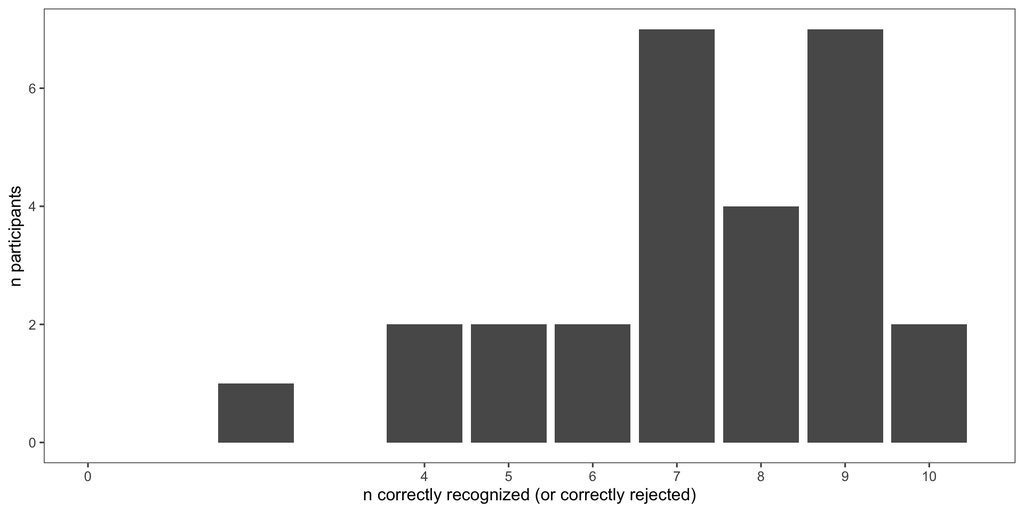

### Slider Practice and Memory Check

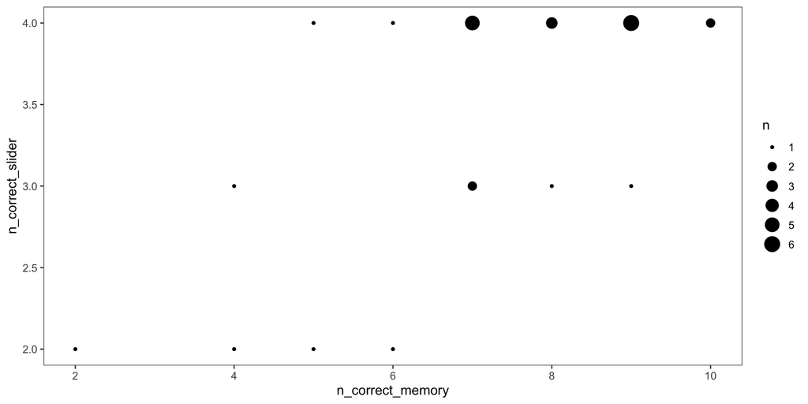

### Explanations of Task

After the story, participants are also asked to explain generally what they did in the experiment.

| workerid | n_slider_correct | n_memory_correct | explanation |
| --- | --- | --- | --- |
| 26a3e94840176c7910e93a530e7f7c61 | 2 | 4 | just describes the scales |
| 345d87f9a0723fec9020dd2c292f552b | 4 | 9 | I answered comprehension questions about a story about a fictional planet |
| c52582d8e5bb6e6b275814185c5ff5fb | 4 | 10 | Learned facts about aliens. |
| 6d689db9b7d331eac4363f9a6a6ec3a2 | 4 | 8 | Read a few sentences and gave a percentage on what we read. |
| db9acf6ed743ca115ab1d9c760359e67 | 4 | 7 | Made percentage choices about some made up nonsense |
| 947e581998a96f562d1b4e4ab7d10e05 | 3 | 7 | Making judgement on some statement |
| c8f825d14e1634ceed189ad6277b1bff | 4 | 8 | I read a children’s book about an Alien planet that taught me about a variety of different species and how they live. |
| 77593aebcb7da310342dade08c7c1c6d | 4 | 7 | I read chapters about an alien planet very similar to earth and learned about different species on their seven continents. |
| cbfd728b8b4b785364dba229a96f403d | 3 | 7 | based on a short story make predictions |
| 012f25f08282560c3a051d9fa256da0a | 4 | 9 | Read a story about a fictional planet, the animal and plant life there, and answered questions about the animals who live there. |
| 92713de97872c3c8f072c1fe598bc289 | 4 | 5 | i had to read about an alien planet and answer questions about what i read |
| 9115909c858d487ba962a3c2ed2a9880 | 4 | 9 | I read a few sentences that made up the chapters of a book about a planet about Dax. Then I answered questions on a scale from 0 to 100 about whether a statement about the previous chapter was true or… |
| ba2747149e90bf13d59044d684927428 | 4 | 7 | read about an alien planet and make estimations applicable to the story’s content. |
| 6db2a004ee6d6b94bde1396fdae5a1d1 | 3 | 9 | I read 21 chapters of text describing fictional continents and creatures, and the creatures habits. |
| 2cc839fd87b54fe8f93cf2b07a03e33e | 4 | 6 | I read a book detailing the creatures and land of an alien planet. |
| 3c1d3dced02667537f6e8124b33cf77f | 4 | 7 | I tried to recall the amounts of person/place/things that were mentioned in the story. |
| 2ecdbc8db200c4b351d62dbc0303872a | 2 | 2 | that was exprimend in very nice and good filed sollusion |
| 810ecc2c5358cb5d1f05ba59401fd7f2 | 2 | 5 | The language meaning on understand continue the experiment. |
| e7922efe6f64a2d4bb46b211aeb26095 | 4 | 7 | Read short text excerpts and try to pick on the clues of most, any, some, none and then make the estimate when the slider came up. |
| 81c96ccf0c3c4a2071cdb45b144ce785 | 3 | 4 | check the languages and read the page and rate it !! |
| 3747e1ec631a24e3f5e7d7ec5a0bec52 | 4 | 9 | I read chapters of a (fake?) storybook about an alien world and provided my best guess on the percentage that is true for a given statement. |
| 43d7f2586e9210aa3b5f9735ee6020c2 | 4 | 8 | I read a story about another planet and its inhabitants and what they did then I put on a slider on how I felt about what was asked |
| 99aca6f558848955f477cfbdfa4e4338 | 3 | 8 | i rated a question after finishing a chapter on 0 to 100% scale. |
| f43829ab257c85972e98da461336fa8a | 4 | 9 | I assumed the percentages sometimes with context. |
| f612b02b92fe76c3141f72c620f34ab4 | 4 | 9 | I read a story and answered questions about the story. |
| c6cc1454c6c1415034c633c4c4dddcc8 | 2 | 6 | I answered questions about passages |
| 1c578c7a4cde35e3a0c6cd33bb0f3de2 | 4 | 10 | I learned about an alien planet and made estimates based on the information given in each chapter. |

## Participants

### Included/Excluded Subject Numbers

Removing participants who got fewer than 7 correct on memory check and didn’t get all 4 sliders. (Participants with bad explanations usually fell into one of these other groups.)

| memory_fail | slider_fail | n |
| --- | --- | --- |
| FALSE | FALSE | 16 |
| FALSE | TRUE | 4 |
| TRUE | FALSE | 2 |
| TRUE | TRUE | 5 |

### Prevalence Estimates by Participant

Histogram of all of a single participant’s prevalence estimates, collapsed across trials and color coded for the number of correct responses on the memory check. * fill = number of correct responses on the memory check (out of 10) * facet = participants

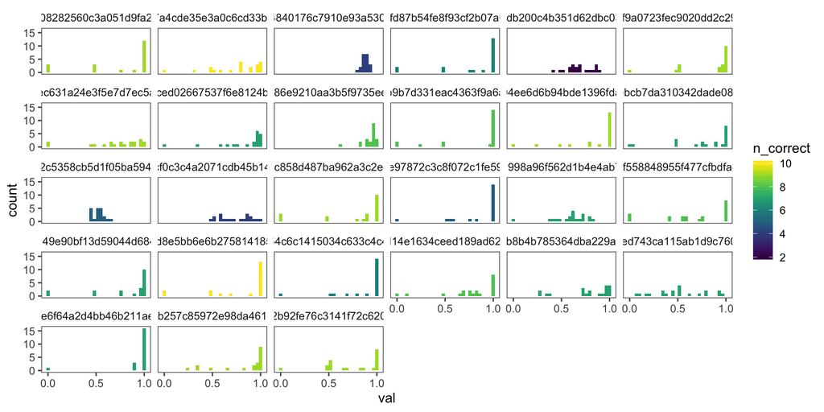

## Filler Trials

These used quantifiers (and thus we have strong idea about literal meaning).

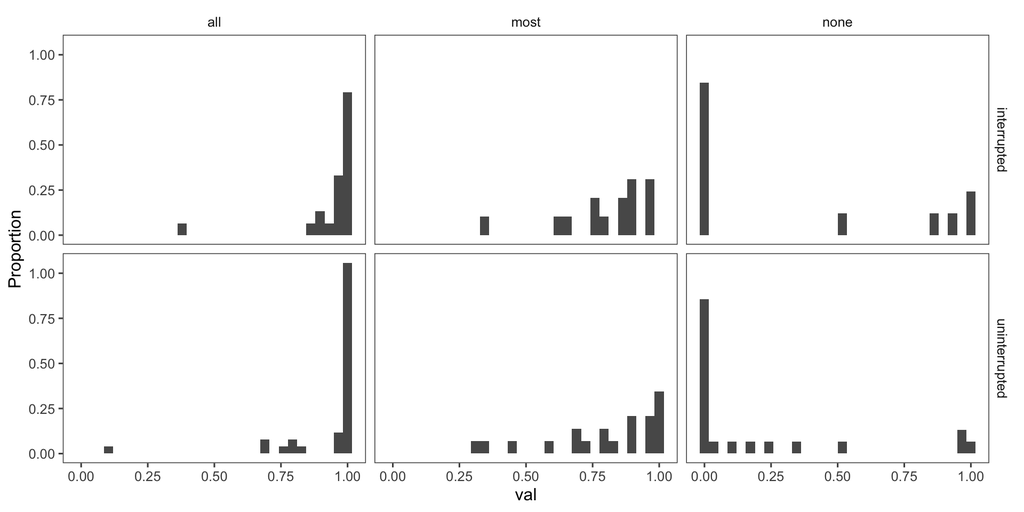

## Critical Trials (collapsed across item)

## Histograms of Prevalence Estimates by Condition (collapsed across item)

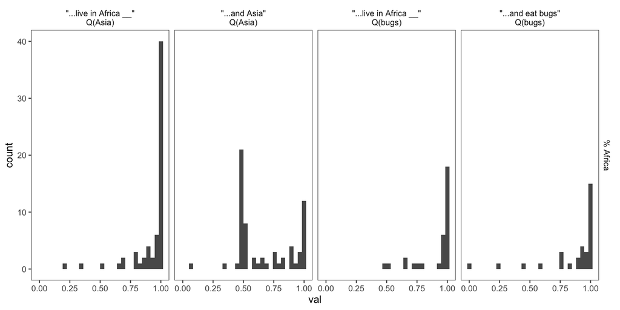

### Bootstrapped 95% Confidence Intervals (collapsed across item)

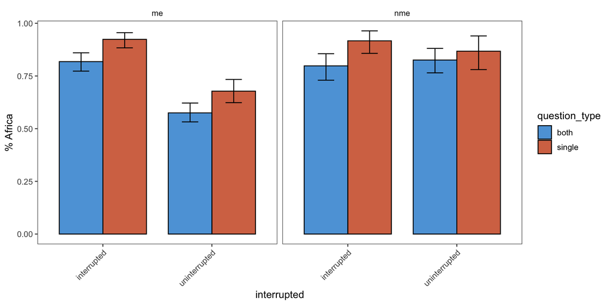

### Pirate Plots (collapsed across item)

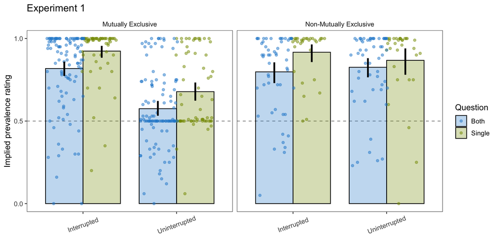

### Ridge Plots

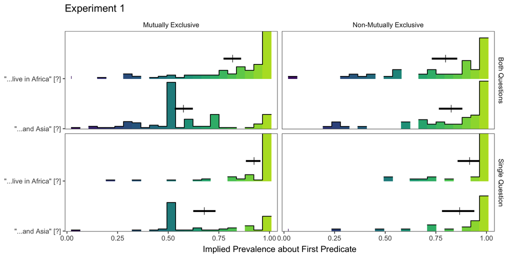

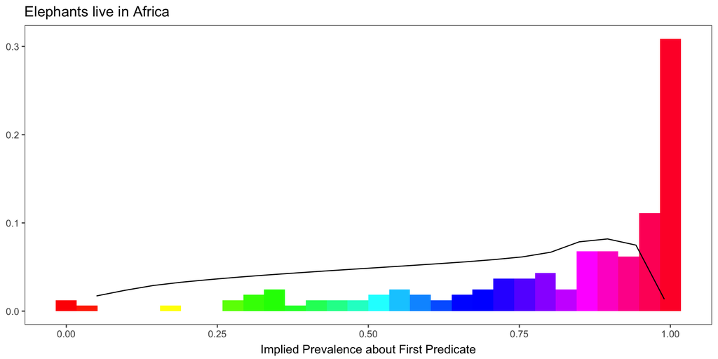

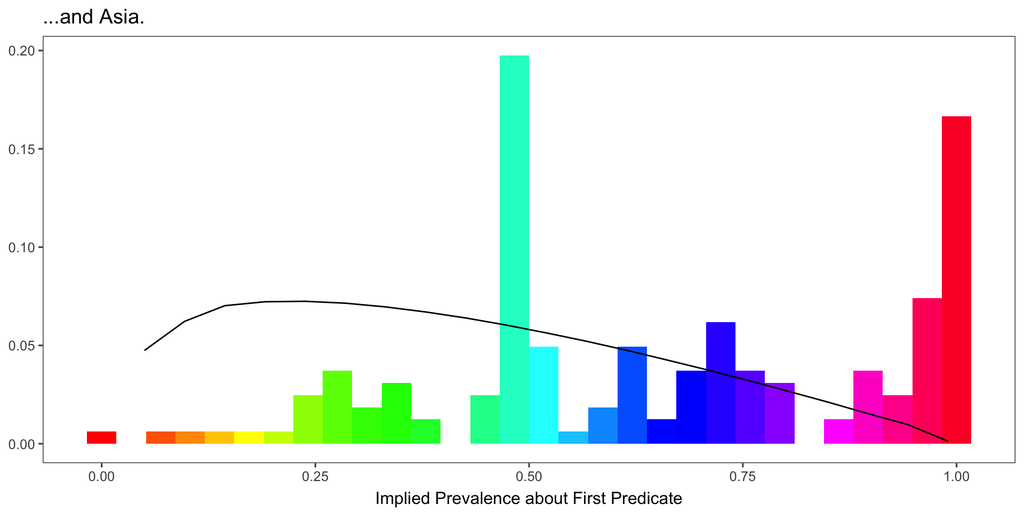

### Stats

#### Regression

[output not shown]

```
##  Family: gaussian
##   Links: mu = identity; sigma = identity
## Formula: val ~ interrupted * me + (1 | workerid) + (1 | predicate_1)
##    Data: model.data %>% filter(question_type == "both") (Number of observations: 324)
##
## The model does not contain posterior samples.
```

[output not shown]

```
##  Family: gaussian
##   Links: mu = identity; sigma = identity
## Formula: val ~ interrupted * me + (1 | workerid) + (1 | predicate_1)
##    Data: model.data %>% filter(question_type == "single") (Number of observations: 192)
##
## The model does not contain posterior samples.
```

### First Trial

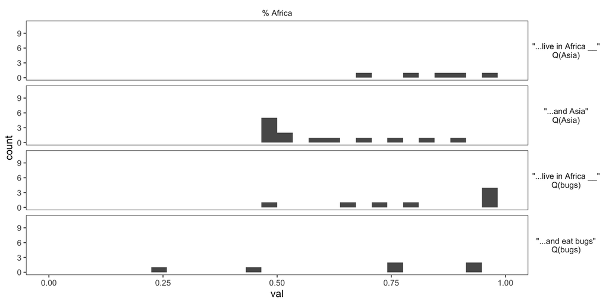

## Reaction Times

*how much time do participants spend on the question slide?*

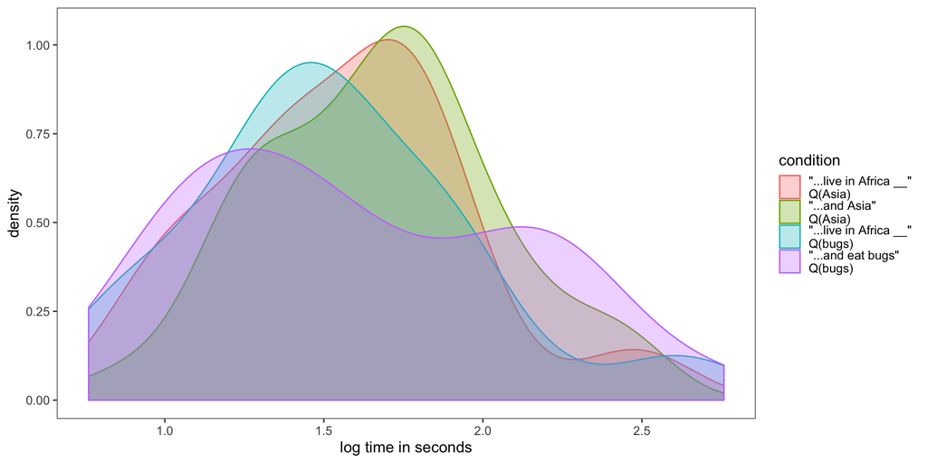